# Homework 5

데이터 분석에 필요한 여러 패키지들과 데이터 프레임이 들어있는 파일을 로드 받는다.

```r
load("C:/Users/sec/Desktop/교과목들/데이터 과학/hw5_student.RData")
```

```r
library(earth)
library(dplyr)
library(tidyr)
```

```r
library(ggplot2)
library(reshape2)
library(caret)
library(ROCR)
library(rpart)
library(class)
library(leaps)
library(kknn)
library(MASS)
```

## Question1

우선 전반적으로 학습 데이터와 훈련 데이터의 구성을 확인한다.

```r
str(student.train)
```

```
## 'data.frame':    861 obs. of  32 variables:
##  $ school    : Factor w/ 2 levels "GP","MS": 2 2 1 1 2 1 1 1 1 1 ...
##  $ sex       : Factor w/ 2 levels "F","M": 1 2 2 2 1 2 2 1 1 1 ...
##  $ age       : int  18 18 17 15 17 18 22 21 17 17 ...
##  $ address   : Factor w/ 2 levels "R","U": 2 2 2 1 1 2 2 2 2 2 ...
##  $ famsize   : Factor w/ 2 levels "GT3","LE3": 2 2 1 1 1 1 1 2 2 2 ...
##  $ Pstatus   : Factor w/ 2 levels "A","T": 1 2 2 2 2 2 2 2 2 2 ...
##  $ Medu      : int  1 1 4 4 2 2 3 4 2 2 ...
##  $ Fedu      : int  1 1 4 4 2 1 1 4 2 2 ...
##  $ Mjob      : Factor w/ 5 levels "at_home","health",..: 1 1 4 3 1 3 4 3 4 3 ...
##  $ Fjob      : Factor w/ 5 levels "at_home","health",..: 4 1 5 3 3 3 4 3 3 3 ...
##  $ reason    : Factor w/ 4 levels "course","home",..: 1 1 2 2 3 2 3 4 1 1 ...
##  $ guardian  : Factor w/ 3 levels "father","mother",..: 2 2 2 1 2 2 2 3 2 1 ...
##  $ traveltime: int  1 2 1 4 1 1 1 1 2 1 ...
##  $ studytime : int  2 2 1 4 1 2 1 3 2 1 ...
```

[output cut: 18 more lines]

```r
str(student.test.nolabel)
```

```
## 'data.frame':    183 obs. of  31 variables:
##  $ school    : Factor w/ 2 levels "GP","MS": 2 1 1 1 1 1 1 2 1 2 ...
##  $ sex       : Factor w/ 2 levels "F","M": 2 1 2 2 2 2 1 2 2 2 ...
##  $ age       : int  19 16 15 18 18 18 17 20 18 17 ...
##  $ address   : Factor w/ 2 levels "R","U": 2 2 2 2 2 1 2 2 1 2 ...
##  $ famsize   : Factor w/ 2 levels "GT3","LE3": 1 1 2 2 1 2 1 2 1 2 ...
##  $ Pstatus   : Factor w/ 2 levels "A","T": 2 2 2 2 2 2 2 1 2 2 ...
##  $ Medu      : int  1 4 4 2 4 3 4 2 2 4 ...
##  $ Fedu      : int  1 4 4 1 4 2 4 2 3 4 ...
##  $ Mjob      : Factor w/ 5 levels "at_home","health",..: 3 2 5 1 5 4 5 4 3 3 ...
##  $ Fjob      : Factor w/ 5 levels "at_home","health",..: 3 3 3 3 4 3 4 4 4 4 ...
##  $ reason    : Factor w/ 4 levels "course","home",..: 3 2 2 1 2 4 1 1 4 2 ...
##  $ guardian  : Factor w/ 3 levels "father","mother",..: 2 2 3 2 1 2 2 3 1 2 ...
##  $ traveltime: int  1 1 1 4 1 2 1 1 1 1 ...
##  $ studytime : int  2 1 1 2 2 3 3 2 1 3 ...
```

[output cut: 17 more lines]

우선 데이터의 큰 구조는 몇 가지 레벨로 구성되어 있는 factor형 변수들과 level(수준)의 의미를 담은 변수는 int형으로 구성되어 있었고 타겟 변수는 학생들의 점수인 int형 변수 G3이다.

우선 저렇게 구성된 여러가지 변수들 중 가장 유의미한 변수들을 추려내고자 여러 과정들을 밟았다.

우선 첫번째로 최량부분집합회귀분석의 결과를 살펴보면 다음과 같다.

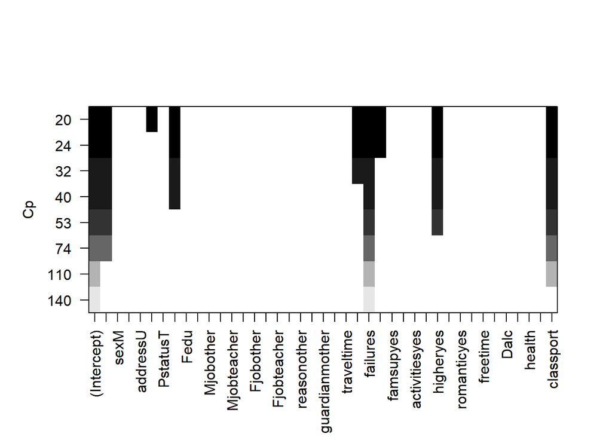

```r
sub.fit <- regsubsets(G3~., data=student.train)
plot(sub.fit, scale = 'Cp')
```

멜로의 Cp통계량 기준 유의미한 변수로는 famsize, Medu, failures, studytume, schoolsup, higher, class등이 있었다.

다른 통계량으로 해도 결과는 엇비슷했다.

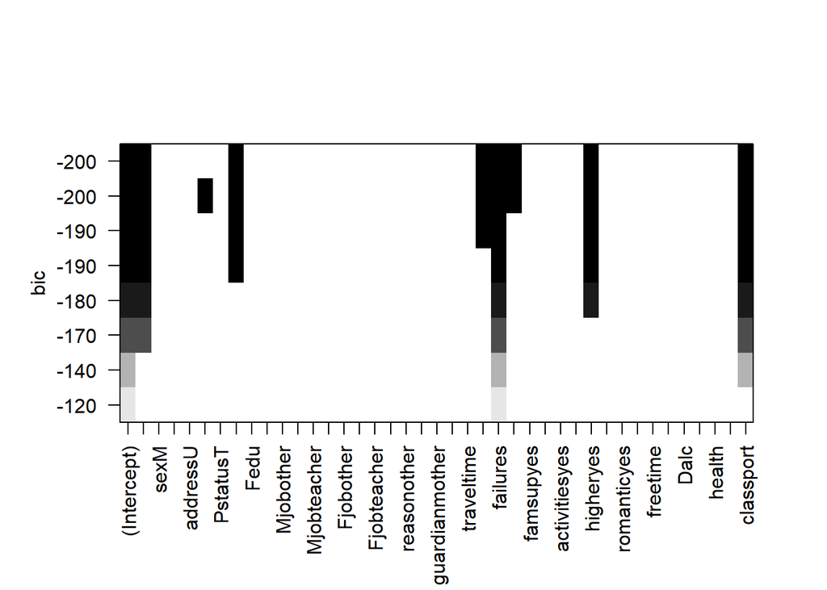

```r
plot(sub.fit, scale = 'bic')
```

이 경우에는 Medu의 영향력이 조금 감소했지만 여전히 강력한 변수들의 영향력은 유사하다.

stepAIC과정을 통해 피처도 뽑아보면

```r
feature <- lm(G3~., data=student.train)
#stepAIC(feature, direction="both")
```

다변량 적응 회귀 스플라인(Multivariate Adaptive Regression Splines)를 적용시킨 경우의 유의미한 피처는 어떠할 지 테스트를 해보면 다음과 같았다.

5겹으로 3회 반복하여 교차검증을 실행한 경우

```r
MARS <- earth(G3~.,data=student.train,nfold=5,ncross=3)
evimp(MARS)
```

```
##              nsubsets   gcv    rss
## failures           20 100.0  100.0
## classport          19  64.9   72.2
## Medu               18  58.0   66.5
## absences           17  50.8   60.7
## studytime          16  45.0   56.0
## goout              15  38.4   51.0
## higheryes          14  33.8   47.3
## schoolsupyes       13  30.5   44.3
## schoolMS           12  27.8   41.8
## freetime           11  24.1   38.7
## famsizeLE3          8  18.1   31.8
## Mjobteacher         6  15.9   27.6
## romanticyes         5  14.1   24.9
## internetyes         4  12.2   22.1
## Fjobteacher         3   8.8   18.5
## health              2   5.2   14.4
## famsupyes           1   2.2    9.9
```

가지치기한 결과를 살펴보면 위의 경우 gcv와 rss의 값을 기준 위의 경우가 유의미한 변수들인데 대개 앞의 경우가 유사한 flow를 보인다. 대체로 failures, class, Medu, absences, studytime, goout, higher등이 유의미한 변수였다.

다른 변수들은 상수로 통제하고 해당 변수의 영향만 보고 싶어 plotmo()를 실행하면

```
##  plotmo grid:    school sex age address famsize Pstatus Medu Fedu  Mjob  Fjob
##                      GP   F  17       U     GT3       T    3    2 other other
##  reason guardian traveltime studytime failures schoolsup famsup paid activities
##  course   mother          1         2        0        no    yes   no        yes
##  nursery higher internet romantic famrel freetime goout Dalc Walc health
##      yes    yes      yes       no      4        3     3    1    2      4
##  absences class
##         2  port
```

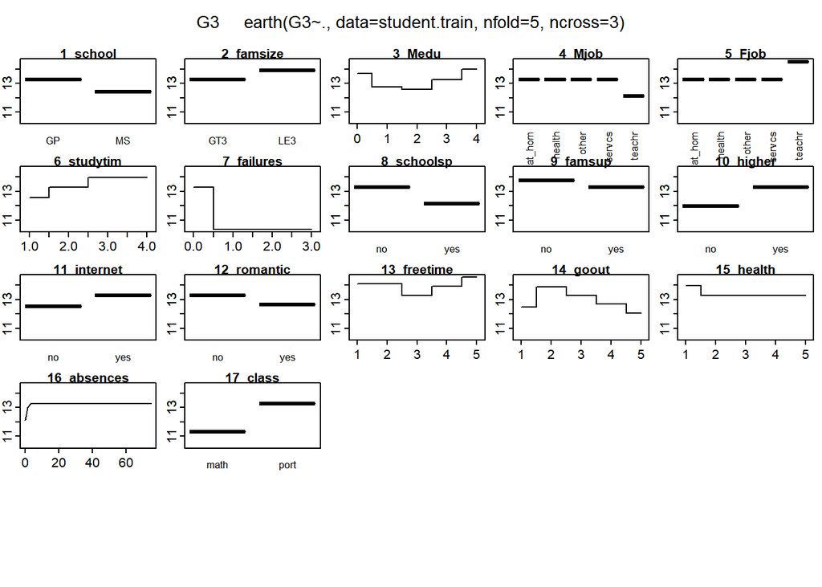

```r
plotmo(MARS)
```

대체로 school, class, famsize, romantic, internet, higher 등의 명확한 차이를 보이는 변수가 유의미할 것으로 판단되고

studytime, goout은 양, 음의 명확한 관계를 보이는 것으로 판단된다.

다만 이것들로 온전한 평가를 내기는 어렵다. 수치의 표준화 부분도 있고 아직 어떠한 전처리도 이루어지지 않았기 때문이다.

# 모델링 과정

Q1.

사실 여기서부터는 솎아낸 변수를 기준으로 이런 저런 전처리 과정을 담았었다. 모든 과정을 다 담기에는 양도 많고 통계적으로 유의미하지 않는 과정이 많았어서 경험적인 flow를 보고서에 담기로 하겠다.

우선, 1) level이 num형태로 표시되어 있었던 변수들을 전부 factor로 바꾼 다음 결과를 시도했을 때는 그냥 numeric형태로 넣었을 때보다는 결과가 좋았다.

2. 저렇게 뽑아낸 결과만 regression 돌린 것 보단 그냥 모든 피처를 때려 박은 것이 서버상의 테스트 셋에 더 결과가 좋았다.
3. 모든 변수를 전부 factorize하는 것보다 부분 부분 점수화를 매겨(numeric으로 전환하여 변수를 처리) 테스트 셋에 적용시킨 것이 더 결과가 좋았다.
4. age, absences와 같이 integer의 폭이 큰 것은 RMSE를 크게하는 소요가 있으므로 이러한 변수들은 전부 group화 하였다.
5. 변수들 간의 유사한 성향을 띄거나 유의미한 영향력을 가질 것 같은 변수들은 하나씩 상호작용 처리를 한 과정을 거쳤다.

물론 더 가용한 시간이 있으면 보다 뛰어난 모델을 만들기 위한 EDA과정을 거칠 수 있으나 시간관계상 최종적으로 만들어진 모델은 다음과 같았다.

```r
# G3~school+address+famsize+Medu+Fedu+Fjob+Mjob+reason*address+I(Medu^2)+
#              guardian*Medu+guardian+studytime+failures+
#              schoolsup+romantic*goout+
#              higher+romantic+sex*activities+sex*goout+class*sex+
#              goout+Dalc+Walc+health+school*studytime+higher*Medu+school*sex+romantic*freetime+
#              health*absence_group+reason*school+nursery*sex+health*goout+absence_group*failures+
#              class+age_group+absence_group+age+age_group*schoolsup+absences+absences*failures+class*sex+
#              higher*studytime+sex*age_group+sex*higher+sex*school+school*studytime+studytime*school+Mjob*paid
#            +romantic*Mjob+romantic*famsize+reason*sex+sex*age_group+failures*sex*failures*schoolsup+failures*class+
#              failures*health+failures*freetime+failures*romantic+schoolsup*activities+higher*school+higher*studytime+
#              health*sex+health*failures+Pstatus*romantic+
#              famsize*Pstatus
```

일련의 전반적인 과정이 Q2~Q6의 과정이다.

우선 최종적으로 만든 데이터 프레임의 형태는 다음과 같다.

```r
student.trains <- student.train
student.tests <- student.test.nolabel
# factor화
student.trains$studytime <- as.factor(student.trains$studytime)
student.tests$studytime <- as.factor(student.tests$studytime)
student.trains$famrel <- as.factor(student.trains$famrel)
student.tests$famrel <- as.factor(student.tests$famrel)
student.trains$freetime <- as.factor(student.trains$freetime)
student.tests$freetime <- as.factor(student.tests$freetime)
student.trains$freetime <- as.factor(student.trains$freetime)
student.tests$freetime <- as.factor(student.tests$freetime)
student.trains$goout <- as.factor(student.trains$goout)
student.tests$goout <- as.factor(student.tests$goout)
student.trains$Dalc <- as.factor(student.trains$Dalc)
student.tests$Dalc <- as.factor(student.tests$Dalc)
student.trains$Walc <- as.factor(student.trains$Walc)
student.tests$Walc <- as.factor(student.tests$Walc)
student.trains$health <- as.factor(student.trains$health)
student.tests$health <- as.factor(student.tests$health)
student.trains$absence_group <- cut(student.trains$absences, breaks=c(0,5,10,15,20,25,30,35), labels=c("1","2","3","4","5","6","7"), right=F)
student.tests$absence_group <- cut(student.tests$absences, breaks=c(0,5,10,15,20,25,30,35), labels=c("1","2","3","4","5","6","7"), right=F)
student.trains$age_group <- cut(student.trains$age, breaks = c(15,16,17,18,19,20,21,Inf), labels = c("1","2","3","4","5","6","7'"), right = F)
student.tests$age_group <- cut(student.tests$age, breaks = c(15,16,17,18,19,20,21,Inf), labels = c("1","2","3","4","5","6","7'"), right = F)
str(student.trains)
```

```
## 'data.frame':    861 obs. of  34 variables:
##  $ school       : Factor w/ 2 levels "GP","MS": 2 2 1 1 2 1 1 1 1 1 ...
##  $ sex          : Factor w/ 2 levels "F","M": 1 2 2 2 1 2 2 1 1 1 ...
##  $ age          : int  18 18 17 15 17 18 22 21 17 17 ...
##  $ address      : Factor w/ 2 levels "R","U": 2 2 2 1 1 2 2 2 2 2 ...
##  $ famsize      : Factor w/ 2 levels "GT3","LE3": 2 2 1 1 1 1 1 2 2 2 ...
##  $ Pstatus      : Factor w/ 2 levels "A","T": 1 2 2 2 2 2 2 2 2 2 ...
##  $ Medu         : int  1 1 4 4 2 2 3 4 2 2 ...
##  $ Fedu         : int  1 1 4 4 2 1 1 4 2 2 ...
##  $ Mjob         : Factor w/ 5 levels "at_home","health",..: 1 1 4 3 1 3 4 3 4 3 ...
##  $ Fjob         : Factor w/ 5 levels "at_home","health",..: 4 1 5 3 3 3 4 3 3 3 ...
##  $ reason       : Factor w/ 4 levels "course","home",..: 1 1 2 2 3 2 3 4 1 1 ...
##  $ guardian     : Factor w/ 3 levels "father","mother",..: 2 2 2 1 2 2 2 3 2 1 ...
##  $ traveltime   : int  1 2 1 4 1 1 1 1 2 1 ...
##  $ studytime    : Factor w/ 4 levels "1","2","3","4": 2 2 1 4 1 2 1 3 2 1 ...
```

[output cut: 20 more lines]

부분부분 Medu, Fedu, traveltime, failures 등은 전부 integer값이고 absence_group, age_group이라는 변수가 추가되었다.

모델은 다음과 같다.

```r
FinalModel <- lm(G3~school+address+famsize+Medu+Fedu+Fjob+Mjob+reason*address+I(Medu^2)+
              guardian*Medu+guardian+studytime+failures+
              schoolsup+romantic*goout+
              higher+romantic+sex*activities+sex*goout+class*sex+
              goout+Dalc+Walc+health+school*studytime+higher*Medu+school*sex+romantic*freetime+
              health*absence_group+reason*school+nursery*sex+health*goout+absence_group*failures+
              class+age_group+absence_group+age+age_group*schoolsup+absences+absences*failures+class*sex+
              higher*studytime+sex*age_group+sex*higher+sex*school+school*studytime+studytime*school+Mjob*paid
            +romantic*Mjob+romantic*famsize+reason*sex+sex*age_group+failures*sex*failures*schoolsup+failures*class+
              failures*health+failures*freetime+failures*romantic+schoolsup*activities+higher*school+higher*studytime+
              health*sex+health*failures+Pstatus*romantic+
              famsize*Pstatus, data=student.trains)
```

다소 피처가 많고 복잡하여 모든 일련의 과정을 설명하긴 어려우나 경험의 과정을 일부 언급하면

우선 무조건 많은 피처를 담는다고 성능이 좋지는 못하였다. 가령, traveltime, famsup같은 변수들은 오히려 RMSE를 높이는 노이즈 값이었다. famsup같은 경우는 직관적으로 보면 G3에 양의 영향을 강하게 미칠 것 같았지만 모델의 결과에서는 그러하지 못하였다.

이 결과는 가족의 교육에 대한 지원이 높다고 무조건 학생의 공부 성적에 큰 영향을 미치지 않을 수도 있음을 시사한다. 또한 traveltime또한 크게 학생들의 성적과 밀접한 관계를 갖지는 않았다. 여행을 많이 간다고 성적이 낮아지고 또는 높아지고와의 어떤 관계성을 띄지 않는 것이다.

또한, Dalc, Walc와 health같은 경우는 공부에 악영향을 미칠 요인이 있을 수 있겠다고 판단하여 상호작용항으로 해 적용을 시켰지만 이 경우는 G3와 어떠한 유의미한 연관성을 보이지 않았다. 앞에서 stepAIC에서 뽑은 베스트 모델에서 저렇게 하나씩 피처를 수정해가며 모델을 돌린 결과가 다음과 같이 나옴을 확인할 수 있었다.

우선 유의미했던 변수들의 영향력 외에도 romantic이나, goout등은 성적에 큰 영향을 미치는 함수였다. 또한 freetime과 goout은 연쇄적으로 변수에 영향을 미쳤으며 higher와 Medu, health와 absences_group도 성적에 큰 영향을 미치는 변수들이었다. 직관적으로도 자유시간이 많아 많이 놀러 나갈수록 성적에 안좋은 영향을 미치며 어머니의 교육 수준이 높아 엄마의 치맛바람이 학생들로 하여금 더 고차원의 커리큘럼을 이수하고자 하게 하는 영향이 있을 것이다. 또한 몸이 안 좋은 학생들의 경우 당연히 결석을 많이 할 것이다. 이러한 여러 직관에 맞는 변수들은 영향력이 다소 크게 작용했음을 경험적으로 확인할 수 있었다.

RMSE를 먼저 체크하기 위한 함수를 정의하고

```r
calcRMSE <- function(label, estimation){
  return(sqrt(mean((label-estimation)**2)))
}
```

해당 모델을 summary해보면 다음과 같았다.

```r
summary(FinalModel)
```

```
##
## Call:
## lm(formula = G3 ~ school + address + famsize + Medu + Fedu +
##     Fjob + Mjob + reason * address + I(Medu^2) + guardian * Medu +
##     guardian + studytime + failures + schoolsup + romantic *
##     goout + higher + romantic + sex * activities + sex * goout +
##     class * sex + goout + Dalc + Walc + health + school * studytime +
##     higher * Medu + school * sex + romantic * freetime + health *
##     absence_group + reason * school + nursery * sex + health *
##     goout + absence_group * failures + class + age_group + absence_group +
##     age + age_group * schoolsup + absences + absences * failures +
##     class * sex + higher * studytime + sex * age_group + sex *
##     higher + sex * school + school * studytime + studytime *
##     school + Mjob * paid + romantic * Mjob + romantic * famsize +
##     reason * sex + sex * age_group + failures * sex * failures *
##     schoolsup + failures * class + failures * health + failures *
##     freetime + failures * romantic + schoolsup * activities +
##     higher * school + higher * studytime + health * sex + health *
##     failures + Pstatus * romantic + famsize * Pstatus, data = student.trains)
##
## Residuals:
##     Min      1Q  Median      3Q     Max
## -10.896  -1.430   0.081   1.857   6.708
##
## Coefficients: (7 not defined because of singularities)
##                              Estimate Std. Error t value Pr(>|t|)
## (Intercept)                -90.833661  95.276389  -0.953 0.340746
## schoolMS                    -0.616663   1.122020  -0.550 0.582776
## addressU                     0.294229   0.462032   0.637 0.524462
## famsizeLE3                  -0.010063   0.825495  -0.012 0.990277
## Medu                        -2.289298   0.817129  -2.802 0.005231 **
## Fedu                         0.120880   0.159615   0.757 0.449120
## Fjobhealth                   0.027960   0.906251   0.031 0.975397
## Fjobother                    0.069466   0.579411   0.120 0.904605
## Fjobservices                 0.238599   0.603841   0.395 0.692868
## Fjobteacher                  1.356455   0.807289   1.680 0.093373 .
## Mjobhealth                   0.356643   0.803704   0.444 0.657367
## Mjobother                   -0.039720   0.469614  -0.085 0.932621
## Mjobservices                 0.051984   0.555542   0.094 0.925476
## Mjobteacher                 -0.257104   0.730052  -0.352 0.724820
```

[output cut: 170 more lines]

```
## schoolMS:higheryes          -0.500999   1.059504  -0.473 0.636465
## sexM:health2                -0.589627   1.109840  -0.531 0.595406
## sexM:health3                 0.155715   0.986013   0.158 0.874564
## sexM:health4                 1.131181   1.002291   1.129 0.259472
## sexM:health5                 0.072441   0.891116   0.081 0.935234
## romanticyes:PstatusT         0.891888   0.845395   1.055 0.291807
## famsizeLE3:PstatusT          0.357525   0.846912   0.422 0.673049
## failures:schoolsupyes:sexM  -0.072440   1.352559  -0.054 0.957303
## ---
## Signif. codes:  0 '***' 0.001 '**' 0.01 '*' 0.05 '.' 0.1 ' ' 1
##
## Residual standard error: 3.148 on 671 degrees of freedom
##   (5 observations deleted due to missingness)
## Multiple R-squared:  0.484,  Adjusted R-squared:  0.3425
## F-statistic:  3.42 on 184 and 671 DF,  p-value: < 2.2e-16
```

상당히 많은 피처들이 사용되어 다소 값이 복잡할 수 있음은 양해를 구한다.

이 경우 R2는 0.484정도 나왔고

RMSE의 경우

```r
finalmodel.train <-  predict(FinalModel, newdata=student.trains)
calcRMSE(student.trains$G3, FinalModel$fitted.values)
```

[output not shown]

최종적인 테스트 모델의 결과는 RMSE가 2.90이었고 R2는 0.41정도 되었다.

학습 데이터에서의 0.484와 큰 차이는 없어 overfitting이 없음을 확인할 수 있다.

최종적인 모델은 FinalModel을 적용시켜 서버에 제출하였다.

## Question 2

우선 학습 데이터와 테스트 데이터의 셋을 살펴보면 다음과 같다.

```r
str(credit_train)
```

```
## 'data.frame':    25000 obs. of  24 variables:
##  $ LIMIT_BAL                 : int  500000 50000 230000 200000 240000 200000 310000 200000 230000 200000 ...
##  $ SEX                       : int  1 1 2 2 2 2 1 1 1 2 ...
##  $ EDUCATION                 : int  1 3 3 1 2 1 1 1 2 2 ...
##  $ MARRIAGE                  : int  2 2 1 1 2 1 1 2 1 1 ...
##  $ AGE                       : int  38 37 37 59 30 38 43 27 51 49 ...
##  $ PAY_1                     : int  -2 2 0 0 0 2 -1 0 2 1 ...
##  $ PAY_2                     : int  -2 2 0 0 0 -1 2 0 0 -2 ...
##  $ PAY_3                     : int  -2 2 0 0 0 2 -1 -1 0 -2 ...
##  $ PAY_4                     : int  -2 3 0 0 0 2 -1 -1 0 -2 ...
##  $ PAY_5                     : int  -2 2 0 0 0 -2 -1 -1 0 -2 ...
##  $ PAY_6                     : int  -2 2 0 0 0 -1 -1 -1 0 -2 ...
##  $ BILL_AMT1                 : int  0 46004 225800 92215 226315 166 2432 58725 204643 -5 ...
##  $ BILL_AMT2                 : int  0 45976 228342 94085 231582 1694 261 76287 197993 728 ...
##  $ BILL_AMT3                 : int  0 48953 189966 96174 226909 1519 2745 22869 84076 0 ...
##  $ BILL_AMT4                 : int  8086 48851 142377 98116 135626 0 -626 30268 77766 0 ...
##  $ BILL_AMT5                 : int  0 49318 143828 99490 138520 0 110 54466 70066 0 ...
##  $ BILL_AMT6                 : int  0 51143 143698 101412 141280 600 -154 37127 62865 0 ...
##  $ PAY_AMT1                  : int  0 1000 8440 4300 9100 1694 0 30229 5805 733 ...
##  $ PAY_AMT2                  : int  0 4035 6100 4500 9859 0 4000 22946 2965 0 ...
##  $ PAY_AMT3                  : int  8086 1000 7000 4438 4147 0 0 30684 3500 0 ...
##  $ PAY_AMT4                  : int  0 1400 5356 3900 3691 0 1000 54589 2600 0 ...
##  $ PAY_AMT5                  : int  0 2800 5400 3800 3700 600 0 37208 2500 0 ...
##  $ PAY_AMT6                  : int  0 0 5200 3500 3729 0 0 55031 1901 0 ...
##  $ default.payment.next.month: int  0 1 0 0 0 1 0 0 0 1 ...
```

```r
str(credit_test)
```

```
## 'data.frame':    5000 obs. of  23 variables:
##  $ LIMIT_BAL: int  80000 20000 50000 60000 140000 20000 200000 230000 20000 260000 ...
##  $ SEX      : int  2 2 2 2 2 1 1 2 1 2 ...
##  $ EDUCATION: int  1 3 2 3 2 2 1 1 2 3 ...
##  $ MARRIAGE : int  1 3 1 3 2 2 1 1 2 1 ...
##  $ AGE      : int  36 32 42 48 26 23 44 35 24 52 ...
##  $ PAY_1    : int  -1 0 0 0 0 0 -1 0 0 1 ...
##  $ PAY_2    : int  -1 0 0 0 0 0 -1 0 0 2 ...
##  $ PAY_3    : int  -2 0 0 2 0 2 -2 -1 0 0 ...
##  $ PAY_4    : int  -2 -2 0 2 0 2 -2 -1 0 0 ...
##  $ PAY_5    : int  -2 -2 0 -1 2 4 -2 -1 4 0 ...
##  $ PAY_6    : int  -1 -1 0 0 0 3 -2 -1 3 0 ...
##  $ BILL_AMT1: int  78780 19446 49401 53116 141057 10208 667 6012 5212 9979 ...
##  $ BILL_AMT2: int  0 20650 47828 55950 144306 14972 0 0 6462 9371 ...
##  $ BILL_AMT3: int  0 0 48416 54439 141949 17432 0 1897 7846 18488 ...
##  $ BILL_AMT4: int  0 0 20098 -561 141345 19548 0 0 10715 27022 ...
##  $ BILL_AMT5: int  0 0 20130 20115 136379 18948 0 89 10406 28402 ...
##  $ BILL_AMT6: int  59349 1000 20158 20000 126211 18358 0 2398 9953 800 ...
##  $ PAY_AMT1 : int  0 2000 2100 3689 7200 4972 0 78 1500 0 ...
##  $ PAY_AMT2 : int  0 0 2000 0 19000 3000 0 1897 1500 10000 ...
##  $ PAY_AMT3 : int  0 0 702 0 10400 2700 0 0 3000 11264 ...
##  $ PAY_AMT4 : int  0 0 718 20907 0 0 0 89 0 1580 ...
##  $ PAY_AMT5 : int  59349 1000 730 400 4931 0 0 2398 0 2 ...
##  $ PAY_AMT6 : int  0 0 632 0 9100 1000 0 671 0 1098 ...
```

수치형 변수가 적합하지 않는 변수들도 수치형 변수로 되어있음을 확인할 수 있다.

1. 우선 첫번째로 SEX, EDUCATION, MARRIAGE, PAY_1~6같은 자명한 factor형 변수는 전부 factorize하는 과정을 거쳤다.

PAY_1~6도 level의 의미이기에 factor로 넣는 것이 더 좋다는 판단을 하였다.

2. AGE의 경우 group으로 나누면 좋겠다는 생각이 들어 범위에 따라 group으로 나누어주었다. 실제로 테스트 적용 결과 그냥 AGE를 넣을 때보다 group화하여 적용시켜준 것이 더 결과가 좋았다.

첫 번째 시도로 LIMIT_BAL과 다른 BILL_AMT 변수들에 대한 크기가 제각각이라 이들을 전부 scaling하여 처리하는 과정을 밟았었다.

우선 factor와 변수 제작 과정은 다음과 같다.

```r
credit_trains <- credit_train
credit_tests <- credit_test
credit_trains$SEX <- as.factor(credit_trains$SEX)
credit_trains$EDUCATION <- as.factor(credit_trains$EDUCATION)
credit_trains$MARRIAGE <- as.factor(credit_trains$MARRIAGE)
credit_tests$SEX <- as.factor(credit_tests$SEX)
credit_tests$EDUCATION <- as.factor(credit_tests$EDUCATION)
credit_tests$MARRIAGE <- as.factor(credit_tests$MARRIAGE)

credit_trains$PAY_1 <- as.factor(credit_trains$PAY_1)
credit_trains$PAY_2 <- as.factor(credit_trains$PAY_2)
credit_trains$PAY_3 <- as.factor(credit_trains$PAY_3)
credit_trains$PAY_4 <- as.factor(credit_trains$PAY_4)
credit_trains$PAY_5 <- as.factor(credit_trains$PAY_5)
credit_trains$PAY_6 <- as.factor(credit_trains$PAY_6)

credit_tests$PAY_1 <- as.factor(credit_tests$PAY_1)
credit_tests$PAY_2 <- as.factor(credit_tests$PAY_2)
credit_tests$PAY_3 <- as.factor(credit_tests$PAY_3)
credit_tests$PAY_4 <- as.factor(credit_tests$PAY_4)
credit_tests$PAY_5 <- as.factor(credit_tests$PAY_5)
credit_tests$PAY_6 <- as.factor(credit_tests$PAY_6)
```

```r
credit_trains$age_group <- cut(credit_trains$AGE, breaks = c(20, 30, 40, 50, 60,70,80), labels = c("1","2","3","4","5","6"), right=F)
credit_tests$age_group <- cut(credit_tests$AGE, breaks = c(20, 30, 40, 50, 60,70,80), labels = c("1","2","3","4","5","6"), right=F)
credit_trains$LIMIT_BAL_GROUP <- cut(credit_trains$LIMIT_BAL, breaks=c(10000,50000,140000,167746,240000,1000000), labels = c("1","2","3","4","5"), right=F)
credit_tests$LIMIT_BAL_GROUP <- cut(credit_tests$LIMIT_BAL, breaks =c(10000,50000,140000,167746,240000,1000000), labels = c("1","2","3","4","5"), right=F )
```

scale한 과정은 다음과 같다.

```r
credit_scale <- data.frame(scale(credit_trains[,c(1,12,13,14,15,16,17,18,19,20,21,22,23)]))
credit_scale$PAY_1 <- credit_trains$PAY_1
credit_scale$PAY_2 <- credit_trains$PAY_2
credit_scale$PAY_3 <- credit_trains$PAY_3
credit_scale$PAY_4 <- credit_trains$PAY_4
credit_scale$PAY_5 <- credit_trains$PAY_5
credit_scale$PAY_6 <- credit_trains$PAY_6

credit_scale_test <- data.frame(scale(credit_tests[,c(1,12,13,14,15,16,17,18,19,20,21,22,23)]))
credit_scale_test$PAY_1 <- credit_tests$PAY_1
credit_scale_test$PAY_2 <- credit_tests$PAY_2
credit_scale_test$PAY_3 <- credit_tests$PAY_3
credit_scale_test$PAY_4 <- credit_tests$PAY_4
credit_scale_test$PAY_5 <- credit_tests$PAY_5
credit_scale_test$PAY_6 <- credit_tests$PAY_6

credit_scale$age_group <- credit_trains$age_group
credit_scale_test$age_group <- credit_tests$age_group

credit_scale$SEX <- credit_trains$SEX
credit_scale_test$SEX <- credit_tests$SEX

credit_scale$EDUCATION <- credit_trains$EDUCATION
credit_scale_test$EDUCATION <- credit_tests$EDUCATION

credit_scale$MARRIAGE <- credit_trains$MARRIAGE
credit_scale_test$MARRIAGE <- credit_tests$MARRIAGE

credit_scale$default.payment.next.month <- credit_trains$default.payment.next.month
```

scale한 결과는 다음과 같다.

```r
str(credit_scale)
```

```
## 'data.frame':    25000 obs. of  24 variables:
##  $ LIMIT_BAL                 : num  2.557 -0.906 0.479 0.248 0.556 ...
##  $ BILL_AMT1                 : num  -0.6948 -0.0733 2.3558 0.551 2.3627 ...
##  $ BILL_AMT2                 : num  -0.6918 -0.0472 2.5094 0.6272 2.5549 ...
##  $ BILL_AMT3                 : num  -0.6763 0.0265 2.0512 0.7045 2.5816 ...
##  $ BILL_AMT4                 : num  -0.547 0.084 1.532 0.847 1.428 ...
##  $ BILL_AMT5                 : num  -0.663 0.146 1.696 0.969 1.609 ...
##  $ BILL_AMT6                 : num  -0.653 0.203 1.752 1.044 1.711 ...
##  $ PAY_AMT1                  : num  -0.3713 -0.3054 0.1847 -0.0881 0.2282 ...
##  $ PAY_AMT2                  : num  -0.2739 -0.0833 0.0142 -0.0614 0.1918 ...
##  $ PAY_AMT3                  : num  0.1643 -0.2436 0.1018 -0.0457 -0.0625 ...
##  $ PAY_AMT4                  : num  -0.3237 -0.229 0.0388 -0.0597 -0.0739 ...
##  $ PAY_AMT5                  : num  -0.3156 -0.1321 0.0383 -0.0666 -0.0731 ...
##  $ PAY_AMT6                  : num  -0.293912 -0.293912 -0.000904 -0.096695 -0.083791 ...
##  $ PAY_1                     : Factor w/ 11 levels "-2","-1","0",..: 1 5 3 3 3 5 2 3 5 4 ...
##  $ PAY_2                     : Factor w/ 11 levels "-2","-1","0",..: 1 5 3 3 3 2 5 3 3 1 ...
##  $ PAY_3                     : Factor w/ 11 levels "-2","-1","0",..: 1 5 3 3 3 5 2 2 3 1 ...
##  $ PAY_4                     : Factor w/ 11 levels "-2","-1","0",..: 1 6 3 3 3 5 2 2 3 1 ...
##  $ PAY_5                     : Factor w/ 10 levels "-2","-1","0",..: 1 4 3 3 3 1 2 2 3 1 ...
##  $ PAY_6                     : Factor w/ 10 levels "-2","-1","0",..: 1 4 3 3 3 2 2 2 3 1 ...
##  $ age_group                 : Factor w/ 6 levels "1","2","3","4",..: 2 2 2 4 2 2 3 1 4 3 ...
##  $ SEX                       : Factor w/ 2 levels "1","2": 1 1 2 2 2 2 1 1 1 2 ...
##  $ EDUCATION                 : Factor w/ 7 levels "0","1","2","3",..: 2 4 4 2 3 2 2 2 3 3 ...
##  $ MARRIAGE                  : Factor w/ 4 levels "0","1","2","3": 3 3 2 2 3 2 2 3 2 2 ...
##  $ default.payment.next.month: int  0 1 0 0 0 1 0 0 0 1 ...
```

해당 scale을 돌린 logistic모델을 구축하면 일반적으로 그냥 변수들을 다 넣은 logistic모형보다 테스트에서의 성능이 더 좋지 못하였다.

그 다음 직관에 의존하여 처리한 전처리는

PAY_1~6과 PAY_AMT1~6 사이의 관계에 대한 추론이었다. 실제로 상환 금액과 상환 이행 여부와 굉장히 밀접한 관련이 있을 것 같다는 생각을 했고, 또한 LIMIT_BALL의 값이 매우 크기에 이를 group화하는 과정을 거쳤다. 이에 대한 최종적인 dataframe과 모델은 다음과 같다.

```r
str(credit_trains)
```

```
## 'data.frame':    25000 obs. of  26 variables:
##  $ LIMIT_BAL                 : int  500000 50000 230000 200000 240000 200000 310000 200000 230000 200000 ...
##  $ SEX                       : Factor w/ 2 levels "1","2": 1 1 2 2 2 2 1 1 1 2 ...
##  $ EDUCATION                 : Factor w/ 7 levels "0","1","2","3",..: 2 4 4 2 3 2 2 2 3 3 ...
##  $ MARRIAGE                  : Factor w/ 4 levels "0","1","2","3": 3 3 2 2 3 2 2 3 2 2 ...
##  $ AGE                       : int  38 37 37 59 30 38 43 27 51 49 ...
##  $ PAY_1                     : Factor w/ 11 levels "-2","-1","0",..: 1 5 3 3 3 5 2 3 5 4 ...
##  $ PAY_2                     : Factor w/ 11 levels "-2","-1","0",..: 1 5 3 3 3 2 5 3 3 1 ...
##  $ PAY_3                     : Factor w/ 11 levels "-2","-1","0",..: 1 5 3 3 3 5 2 2 3 1 ...
##  $ PAY_4                     : Factor w/ 11 levels "-2","-1","0",..: 1 6 3 3 3 5 2 2 3 1 ...
##  $ PAY_5                     : Factor w/ 10 levels "-2","-1","0",..: 1 4 3 3 3 1 2 2 3 1 ...
##  $ PAY_6                     : Factor w/ 10 levels "-2","-1","0",..: 1 4 3 3 3 2 2 2 3 1 ...
##  $ BILL_AMT1                 : int  0 46004 225800 92215 226315 166 2432 58725 204643 -5 ...
##  $ BILL_AMT2                 : int  0 45976 228342 94085 231582 1694 261 76287 197993 728 ...
##  $ BILL_AMT3                 : int  0 48953 189966 96174 226909 1519 2745 22869 84076 0 ...
##  $ BILL_AMT4                 : int  8086 48851 142377 98116 135626 0 -626 30268 77766 0 ...
##  $ BILL_AMT5                 : int  0 49318 143828 99490 138520 0 110 54466 70066 0 ...
##  $ BILL_AMT6                 : int  0 51143 143698 101412 141280 600 -154 37127 62865 0 ...
##  $ PAY_AMT1                  : int  0 1000 8440 4300 9100 1694 0 30229 5805 733 ...
##  $ PAY_AMT2                  : int  0 4035 6100 4500 9859 0 4000 22946 2965 0 ...
##  $ PAY_AMT3                  : int  8086 1000 7000 4438 4147 0 0 30684 3500 0 ...
##  $ PAY_AMT4                  : int  0 1400 5356 3900 3691 0 1000 54589 2600 0 ...
##  $ PAY_AMT5                  : int  0 2800 5400 3800 3700 600 0 37208 2500 0 ...
##  $ PAY_AMT6                  : int  0 0 5200 3500 3729 0 0 55031 1901 0 ...
##  $ default.payment.next.month: int  0 1 0 0 0 1 0 0 0 1 ...
##  $ age_group                 : Factor w/ 6 levels "1","2","3","4",..: 2 2 2 4 2 2 3 1 4 3 ...
##  $ LIMIT_BAL_GROUP           : Factor w/ 5 levels "1","2","3","4",..: 5 2 4 4 5 4 5 4 4 4 ...
```

여기서 pred랑 pred_logic은 모델링의 결과를 담아내기 위한 변수이므로 모델 자체에 새롭게 만든 변수는 아니다.

```r
Final_logic <- glm(default.payment.next.month~PAY_1*PAY_AMT1+PAY_2*PAY_AMT2+PAY_3*PAY_AMT3+PAY_4*PAY_AMT4+PAY_5*PAY_AMT5+PAY_6*PAY_AMT6+LIMIT_BAL_GROUP+SEX+EDUCATION+MARRIAGE+BILL_AMT1+BILL_AMT2+BILL_AMT3+BILL_AMT4+BILL_AMT5+BILL_AMT6+age_group+SEX*MARRIAGE,data=credit_trains, family=binomial)
```

적용시킨 모델에 대한 타겟변수 대비 평균 확률 치는 다음과 같았다.

```r
credit_trains$pred <- predict(Final_logic, newdata=credit_trains,type='response')
aggregate(pred~default.payment.next.month,data=credit_trains,mean)
```

```
##   default.payment.next.month      pred
## 1                          0 0.1718549
## 2                          1 0.3963673
```

개략 저 사이에서 precision과 recall을 조정하여 적합한 값을 찾기로 했고 궁극적으로 AUC level을 높게하는 모델을 찾고자 했다.

threshold를 0.2정도로 설정하여 나온 테이블은 다음과 같다.

```r
threshold5 <- 0.2
credit_trains$pred_logic <- ifelse(credit_trains$pred > threshold5, 1, 0)
tb3 <- table(pred=credit_trains$pred_logic, actual=credit_trains$default.payment.next.month)
tb3
```

```
##     actual
## pred     0     1
##    0 15306  2046
##    1  4153  3494
```

그렇게 해서 구한 최종 모델의 학습 데이터에서의 AUC는 다음과 같다.

```r
p <- prediction(credit_trains$pred, credit_trains$default.payment.next.month)
auc3 <- performance(p, 'auc')
auc3@y.values[[1]]
```

```
## [1] 0.7805672
```

실제로 테스트 셋에서의 AUC는 0.763이 나와 큰 차이가 없음을 확인했다. 이렇게 최종 모델을 구축하게 되었다.